# Probeklausur WT33 Wissenschaftliches Arbeiten und Statistische Datenanalyse

### Freitag, 14.01.2022, 10:15 Uhr - 11:00 Uhr, Dauer: 45 Minuten

### 50 Punkte

### Regeln

- Alle Hilfsmittel sind erlaubt
- Eine Kommunikation der Prüfungsteilnehmer untereinander ist während der Prüfung nicht erlaubt
- Der Bearbeitungszeitraum muss selbständig eingehalten werden. Die Zeit startet sobald alle einführenden Hinweise gegeben wurden.
- Diese Regeln müssen von den Prüfungsteilnehmern eingehalten werden und werden durch die Teilnahme an der Prüfung automatisch bestätigt.

Name:

Matrikelnummer:

## Hinweise

### Während der Bearbeitung:

- Lesen Sie die Angaben vollständig.
- Geben Sie für alle notwendigen Lösungsschritte den geeigneten Python Code an.
- Verwenden Sie beliebig viele Zwischenschritte oder Teillösungen.
- Erzeugen Sie so viele Zellen im Notebook, wie Sie benötigen. Es gibt keine Obergrenze.

### Bei Problemen:

- Ihr Code ist nicht lauffähig bzw. Fehler lassen sich nicht beheben.
  - Lösung: Lassen Sie den nicht-lauffähigen Code im Notebook und versuchen Sie Ihren Gedankengang zu Lösung des Problems schriftlich darzulegen. Benutzen Sie dazu entweder Kommentare (Code-Zeile beginnt mit #) oder eine zusätzliche Markdown-Zelle.
- Eine Zelle lässt sich nicht ausführen:
  - Kein Kernel ausgewählt
    - Lösung: Python Kernel auswählen

[figure not shown]

  - Falscher Zelltyp gewählt
    - Lösung: Den richtigen Zelltyp in der Menuleiste auswählen. Zellen mit Python-Code haben zwei rechteckige Klammern an der linken Seite: []

[figure not shown]

- Binder Session endet/Verbindung bricht ab (z.B. nach 10 Minuten ohne Aktivität)

  Lösung:
  1. Browser *NICHT* schließen.
  2. Bestätigen Sie ggf. die Fehlermeldung mit "Dismiss"

[figure not shown]

  3. Speichern Sie den ihr Notebook im Browser Speicher:

[figure not shown]

  4. Öffnen Sie einen neuen Tab
  5. Stellen Sie die Verbindung zum Notebook erneut her, indem Sie den Link aus Moodle zur Prüfung aufrufen bzw. in die Adresszeile des neuen Tabs einfügen.
  6. Stellen Sie das ursprüngliche Notebook aus dem Browserspeicher wieder her:

[figure not shown]

### Nach Ablauf der Bearbeitungszeit:

- Laden Sie das Notebook mit dem Download-Button auf Ihre lokale Festplatte herunter.

[figure not shown]

- Benennen Sie die Datei wie folgt: NACHNAME_MATRIKELNUMMER_WT33_PK_WS21.ipynb
- Geben Sie das Notebook ab indem Sie die Datei (bzw. ggf. auch mehrere Dateien) in der Aufgabe in Moodle hochladen.

## Aufgaben

*Ab hier geht es los - Viel Erfolg!*

### Aufgabe 0

[0 Punkte] Vorbereitung

```python
import pandas as pd
import matplotlib.pyplot as plt
nba = pd.read_csv("nba_all_elo.csv")
pd.set_option("display.max.columns", None)
```

### Aufgabe 1

[2 Punkte] Geben Sie die ersten 15 Zeilen des DataFrames aus.

```python
#Antwort:
nba.head(15)
```

|  | gameorder | game_id | lg_id | _iscopy | year_id | date_game | seasongame | is_playoffs | team_id | fran_id | pts | elo_i | elo_n | win_equiv | opp_id | opp_fran | opp_pts | opp_elo_i | opp_elo_n | game_location | game_result | forecast | notes |
| --- | --- | --- | --- | --- | --- | --- | --- | --- | --- | --- | --- | --- | --- | --- | --- | --- | --- | --- | --- | --- | --- | --- | --- |
| 0 | 1 | 194611010TRH | NBA | 0 | 1947 | 11/1/1946 | 1 | 0 | TRH | Huskies | 66 | 1300.0000 | 1293.2767 | 40.294830 | NYK | Knicks | 68 | 1300.0000 | 1306.7233 | H | L | 0.640065 | NaN |
| 1 | 1 | 194611010TRH | NBA | 1 | 1947 | 11/1/1946 | 1 | 0 | NYK | Knicks | 68 | 1300.0000 | 1306.7233 | 41.705170 | TRH | Huskies | 66 | 1300.0000 | 1293.2767 | A | W | 0.359935 | NaN |
| 2 | 2 | 194611020CHS | NBA | 0 | 1947 | 11/2/1946 | 1 | 0 | CHS | Stags | 63 | 1300.0000 | 1309.6521 | 42.012257 | NYK | Knicks | 47 | 1306.7233 | 1297.0712 | H | W | 0.631101 | NaN |
| 3 | 2 | 194611020CHS | NBA | 1 | 1947 | 11/2/1946 | 2 | 0 | NYK | Knicks | 47 | 1306.7233 | 1297.0712 | 40.692783 | CHS | Stags | 63 | 1300.0000 | 1309.6521 | A | L | 0.368899 | NaN |
| 4 | 3 | 194611020DTF | NBA | 0 | 1947 | 11/2/1946 | 1 | 0 | DTF | Falcons | 33 | 1300.0000 | 1279.6189 | 38.864048 | WSC | Capitols | 50 | 1300.0000 | 1320.3811 | H | L | 0.640065 | NaN |
| 5 | 3 | 194611020DTF | NBA | 1 | 1947 | 11/2/1946 | 1 | 0 | WSC | Capitols | 50 | 1300.0000 | 1320.3811 | 43.135952 | DTF | Falcons | 33 | 1300.0000 | 1279.6189 | A | W | 0.359935 | NaN |
| 6 | 4 | 194611020PRO | NBA | 1 | 1947 | 11/2/1946 | 1 | 0 | BOS | Celtics | 53 | 1300.0000 | 1294.8458 | 40.459381 | PRO | Steamrollers | 59 | 1300.0000 | 1305.1542 | A | L | 0.359935 | NaN |
| 7 | 4 | 194611020PRO | NBA | 0 | 1947 | 11/2/1946 | 1 | 0 | PRO | Steamrollers | 59 | 1300.0000 | 1305.1542 | 41.540619 | BOS | Celtics | 53 | 1300.0000 | 1294.8458 | H | W | 0.640065 | NaN |
| 8 | 5 | 194611020STB | NBA | 1 | 1947 | 11/2/1946 | 1 | 0 | PIT | Ironmen | 51 | 1300.0000 | 1295.3092 | 40.507980 | STB | Bombers | 56 | 1300.0000 | 1304.6908 | A | L | 0.359935 | NaN |
| 9 | 5 | 194611020STB | NBA | 0 | 1947 | 11/2/1946 | 1 | 0 | STB | Bombers | 56 | 1300.0000 | 1304.6908 | 41.492020 | PIT | Ironmen | 51 | 1300.0000 | 1295.3092 | H | W | 0.640065 | NaN |
| 10 | 6 | 194611030CLR | NBA | 1 | 1947 | 11/3/1946 | 2 | 0 | TRH | Huskies | 60 | 1293.2767 | 1286.1534 | 39.548164 | CLR | Rebels | 71 | 1300.0000 | 1307.1233 | A | L | 0.351068 | NaN |
| 11 | 6 | 194611030CLR | NBA | 0 | 1947 | 11/3/1946 | 1 | 0 | CLR | Rebels | 71 | 1300.0000 | 1307.1233 | 41.747120 | TRH | Huskies | 60 | 1293.2767 | 1286.1534 | H | W | 0.648932 | NaN |
| 12 | 7 | 194611040PIT | NBA | 0 | 1947 | 11/4/1946 | 2 | 0 | PIT | Ironmen | 56 | 1295.3092 | 1277.9456 | 38.689037 | WSC | Capitols | 71 | 1320.3811 | 1337.7448 | H | L | 0.606189 | NaN |
| 13 | 7 | 194611040PIT | NBA | 1 | 1947 | 11/4/1946 | 2 | 0 | WSC | Capitols | 71 | 1320.3811 | 1337.7448 | 44.946995 | PIT | Ironmen | 56 | 1295.3092 | 1277.9456 | A | W | 0.393811 | NaN |
| 14 | 8 | 194611050BOS | NBA | 0 | 1947 | 11/5/1946 | 2 | 0 | BOS | Celtics | 55 | 1294.8458 | 1288.4139 | 39.785030 | CHS | Stags | 57 | 1309.6521 | 1316.0840 | H | L | 0.620204 | NaN |

### Aufgabe 2

[8 Punkte] Erzeugen Sie einen Dataframe mit der Bezeichnung `celtics_playoffs`, der nur die Playoff-Spiele der Boston Celtics (`team_id` BOS) enthält. Hinweis: Benutzen Sie dazu das Flag in Spalte `is_playoffs`.

Geben Sie außerdem einen Auszug des Dataframes aus (z.B. die ersten 10 Zeilen des DataFrames)

```python
#Antwort:

celtics_playoffs = nba[( nba["team_id"] == 'BOS' )  &  ( nba["is_playoffs"] == 1  ) ]

celtics_playoffs.head(20)
```

|  | gameorder | game_id | lg_id | _iscopy | year_id | date_game | seasongame | is_playoffs | team_id | fran_id | pts | elo_i | elo_n | win_equiv | opp_id | opp_fran | opp_pts | opp_elo_i | opp_elo_n | game_location | game_result | forecast | notes |
| --- | --- | --- | --- | --- | --- | --- | --- | --- | --- | --- | --- | --- | --- | --- | --- | --- | --- | --- | --- | --- | --- | --- | --- |
| 1097 | 549 | 194803280BOS | NBA | 0 | 1948 | 3/28/1948 | 49 | 1 | BOS | Celtics | 72 | 1312.5914 | 1304.9589 | 31.554913 | CHS | Stags | 79 | 1438.3618 | 1445.9944 | H | L | 0.462981 | NaN |
| 1102 | 552 | 194803310BOS | NBA | 0 | 1948 | 3/31/1948 | 50 | 1 | BOS | Celtics | 81 | 1304.9589 | 1312.2666 | 32.283836 | CHS | Stags | 77 | 1445.9944 | 1438.6866 | H | W | 0.441218 | NaN |
| 1108 | 555 | 194804020BOS | NBA | 0 | 1948 | 4/2/1948 | 51 | 1 | BOS | Celtics | 74 | 1312.2666 | 1304.6532 | 31.524557 | CHS | Stags | 81 | 1438.6866 | 1446.3000 | H | L | 0.462052 | NaN |
| 3785 | 1893 | 195103200BOS | NBA | 0 | 1951 | 3/20/1951 | 70 | 1 | BOS | Celtics | 69 | 1506.6257 | 1488.9506 | 39.948803 | NYK | Knicks | 83 | 1510.8330 | 1528.5082 | H | L | 0.634467 | NaN |
| 3795 | 1898 | 195103220NYK | NBA | 1 | 1951 | 3/22/1951 | 71 | 1 | BOS | Celtics | 78 | 1488.9506 | 1481.7932 | 39.198959 | NYK | Knicks | 92 | 1528.5082 | 1535.6655 | A | L | 0.309308 | NaN |
| 4498 | 2250 | 195203190BOS | NBA | 0 | 1952 | 3/19/1952 | 67 | 1 | BOS | Celtics | 105 | 1574.9653 | 1582.4563 | 48.504478 | NYK | Knicks | 94 | 1579.5975 | 1572.1066 | H | W | 0.633899 | NaN |
| 4508 | 2255 | 195203230NYK | NBA | 1 | 1952 | 3/23/1952 | 68 | 1 | BOS | Celtics | 97 | 1582.4563 | 1578.0449 | 48.056339 | NYK | Knicks | 101 | 1572.1066 | 1576.5179 | A | L | 0.373772 | NaN |
| 4514 | 2258 | 195203260BOS | NBA | 0 | 1952 | 3/26/1952 | 69 | 1 | BOS | Celtics | 87 | 1578.0449 | 1572.3955 | 47.479900 | NYK | Knicks | 88 | 1576.5179 | 1582.1674 | H | L | 0.642088 | NaN |
| 5251 | 2626 | 195303190SYR | NBA | 1 | 1953 | 3/19/1953 | 72 | 1 | BOS | Celtics | 87 | 1584.0746 | 1596.8373 | 50.079281 | SYR | Sixers | 81 | 1646.4547 | 1633.6920 | A | W | 0.281965 | NaN |
| 5257 | 2629 | 195303210BOS | NBA | 0 | 1953 | 3/21/1953 | 73 | 1 | BOS | Celtics | 111 | 1596.8373 | 1602.8749 | 50.679440 | SYR | Sixers | 105 | 1633.6920 | 1627.6544 | H | W | 0.589886 | NaN |
| 5266 | 2634 | 195303250NYK | NBA | 1 | 1953 | 3/25/1953 | 74 | 1 | BOS | Celtics | 91 | 1602.8749 | 1599.1079 | 50.305485 | NYK | Knicks | 95 | 1627.8087 | 1631.5757 | A | L | 0.327574 | NaN |
| 5269 | 2635 | 195303260BOS | NBA | 0 | 1953 | 3/26/1953 | 75 | 1 | BOS | Celtics | 86 | 1599.1079 | 1609.8855 | 51.370834 | NYK | Knicks | 70 | 1631.5757 | 1620.7981 | H | W | 0.595981 | NaN |
| 5275 | 2638 | 195303280NYK | NBA | 1 | 1953 | 3/28/1953 | 76 | 1 | BOS | Celtics | 82 | 1609.8855 | 1599.8497 | 50.379257 | NYK | Knicks | 101 | 1620.7981 | 1630.8339 | A | L | 0.345594 | NaN |
| 5276 | 2639 | 195303290BOS | NBA | 0 | 1953 | 3/29/1953 | 77 | 1 | BOS | Celtics | 75 | 1599.8497 | 1589.1995 | 49.314182 | NYK | Knicks | 82 | 1630.8339 | 1641.4841 | H | L | 0.598036 | NaN |
| 5943 | 2972 | 195403160NYK | NBA | 1 | 1954 | 3/16/1954 | 73 | 1 | BOS | Celtics | 93 | 1599.2255 | 1618.9003 | 51.778790 | NYK | Knicks | 71 | 1532.0281 | 1512.3533 | A | W | 0.452933 | Round Robin |
| 5947 | 2974 | 195403170BOS | NBA | 0 | 1954 | 3/17/1954 | 74 | 1 | BOS | Celtics | 95 | 1618.9003 | 1613.4047 | 51.240211 | SYR | Sixers | 96 | 1626.6836 | 1632.1792 | H | L | 0.629679 | Round Robin |
| 5954 | 2978 | 195403200BOS | NBA | 0 | 1954 | 3/20/1954 | 75 | 1 | BOS | Celtics | 79 | 1613.4047 | 1615.0436 | 51.401234 | NYK | Knicks | 78 | 1509.2047 | 1507.5658 | H | W | 0.764132 | Round Robin |
| 5963 | 2982 | 195403220SYR | NBA | 1 | 1954 | 3/22/1954 | 76 | 1 | BOS | Celtics | 85 | 1615.0436 | 1607.7805 | 50.685108 | SYR | Sixers | 98 | 1641.0214 | 1648.2844 | A | L | 0.326252 | Round Robin |
| 5966 | 2984 | 195403250SYR | NBA | 1 | 1954 | 3/25/1954 | 77 | 1 | BOS | Celtics | 94 | 1607.7805 | 1600.3215 | 49.943100 | SYR | Sixers | 109 | 1648.2844 | 1655.7434 | A | L | 0.308145 | NaN |
| 5969 | 2985 | 195403270BOS | NBA | 0 | 1954 | 3/27/1954 | 78 | 1 | BOS | Celtics | 76 | 1600.3215 | 1590.4844 | 48.955105 | SYR | Sixers | 83 | 1655.7434 | 1665.5806 | H | L | 0.563803 | NaN |

**Hinweis** Sollten sie Aufgabe 2 nicht gelöst haben so führen Sie bitte folgendes Statment aus, um mit dem korrekten DataFrame weiterzuarbeiten.

```python
celtics_playoffs = pd.read_csv("celtics.csv")
```

### Aufgabe 3

[3 Punkte] Wie viele Spiele haben die Celtics insgesamt in den Playoffs absolviert?

```python
#Antwort:
celtics_playoffs.describe()
```

|  | gameorder | _iscopy | year_id | seasongame | is_playoffs | pts | elo_i | elo_n | win_equiv | opp_pts | opp_elo_i | opp_elo_n | forecast |
| --- | --- | --- | --- | --- | --- | --- | --- | --- | --- | --- | --- | --- | --- |
| count | 601.000000 | 601.000000 | 601.000000 | 601.000000 | 601.0 | 601.000000 | 601.000000 | 601.000000 | 601.000000 | 601.000000 | 601.000000 | 601.000000 | 601.000000 |
| mean | 25311.813644 | 0.469218 | 1981.775374 | 87.750416 | 1.0 | 104.948419 | 1626.711039 | 1627.308368 | 54.083420 | 102.384359 | 1585.746617 | 1585.149290 | 0.559417 |
| std | 18658.285294 | 0.499467 | 17.934170 | 7.744521 | 0.0 | 14.941519 | 72.357887 | 72.467510 | 6.644233 | 13.743496 | 74.660837 | 74.715331 | 0.179056 |
| min | 549.000000 | 0.000000 | 1948.000000 | 49.000000 | 1.0 | 66.000000 | 1304.958900 | 1304.653200 | 31.524557 | 64.000000 | 1369.517600 | 1369.517600 | 0.129548 |
| 25% | 7144.000000 | 0.000000 | 1966.000000 | 84.000000 | 1.0 | 94.000000 | 1579.239000 | 1582.787400 | 50.412148 | 93.000000 | 1533.300000 | 1533.001700 | 0.415930 |
| 50% | 22815.000000 | 0.000000 | 1981.000000 | 87.000000 | 1.0 | 105.000000 | 1639.609600 | 1641.380700 | 55.865044 | 102.000000 | 1577.533800 | 1576.903700 | 0.575394 |
| 75% | 34471.000000 | 1.000000 | 1992.000000 | 92.000000 | 1.0 | 115.000000 | 1676.591300 | 1676.591300 | 58.513615 | 111.000000 | 1640.310500 | 1640.947800 | 0.711815 |
| max | 63103.000000 | 1.000000 | 2015.000000 | 108.000000 | 1.0 | 157.000000 | 1815.691800 | 1815.691800 | 68.242737 | 145.000000 | 1781.762900 | 1769.108800 | 0.931039 |

```python
celtics_playoffs["game_id"].count()
```

```
601
```

### Aufgabe 4

[4 Punkte] Wie viele Spiele haben die Celtics insgesamt in den Playoffs **gewonnen**?

```python
#Antwort:
celtics_playoffs.loc[celtics_playoffs["game_result"] == 'W' , "game_id" ].count()
```

```
344
```

```python
celtics_playoffs_w = celtics_playoffs[celtics_playoffs["game_result"] == 'W' ]
```

```python
celtics_playoffs_w["game_id"].count()
```

```
344
```

### Aufgabe 5

[3 Punkte] Erzeugen Sie einen Boxplot, der die Häufigkeitsverteilung der erzielten Punkte der Celtics in allen Playoff-Spielen darstellt.

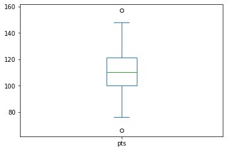

```python
#Antwort:

celtics_playoffs_w["pts"].plot(kind='box')
```

### Aufgabe 6

[6 Punkte] Welche Bedeutung hat der horizontale Strich in der Mitte der Box? Wie wird dieser Lageparameter genannt?

Welche Bedeutung haben die beiden Punkte am oberen Ende der Darstellung? Warum werden sie so dargestellt?

[figure not shown]

Antwort:

### Aufgabe 7

[2 Punkte] Geben Sie den genauen Wert des Lageparameters aus Aufgabe 6 aus.

```python
#Antwort:
celtics_playoffs["pts"].median()
```

```
105.0
```

```python
#zum Vergleich der arithmetische Mittelwert
celtics_playoffs["pts"].mean()
```

```
104.94841930116472
```

### Aufgabe 8

[6 Punkte] Gegeben sind die beiden u.g. Code-Fragmente. Was wird hier jeweils berechnet?

```python
celtics_playoffs[celtics_playoffs["game_result"] == "W"].pts.mean()
```

```
110.3313953488372
```

```python
celtics_playoffs[celtics_playoffs["game_result"] == "L"].pts.mean()
```

```
97.7431906614786
```

Antwort:

### Aufgabe 9

[6 Punkte] Geben Sie ein Statement an, dass die beiden Berechnungen aus Aufgabe 8 vereint und zwei Zeilen auf einmal ausgibt.

Hinweis: Die Berechnung wird nun nicht mehr für explizit festgelegt Werte der Spalte `game_result` durchgeführt sondern für jeden gefundenen Wert **gruppenweise** erledigt.

```python
#Antwort:
celtics_playoffs.groupby("game_result").pts.mean()
```

```
game_result
L     97.743191
W    110.331395
Name: pts, dtype: float64
```

### Aufgabe 10

[3 Punkte] Um die Verteilung der der Gegner in den verlorenen Spielen der Celtics zu analysieren wird Ihnen folgendes Statement vorgelegt. Wieso schlägt das Statement fehl?

```python
celtics_playoffs[celtics_playoffs["game_result"] == "L"].opp_id.mean()
```

```
---------------------------------------------------------------------------
ValueError                                Traceback (most recent call last)
C:\ProgramData\Anaconda3\lib\site-packages\pandas\core\nanops.py in _ensure_numeric(x)
   1601         try:
-> 1602             x = float(x)
   1603         except (TypeError, ValueError):

ValueError: could not convert string to float: 'CHSCHSNYKNYKNYKNYKNYKNYKNYKSYRSYRSYRSYRNYKSYRSYRSYRSYRSYRSTL…'

During handling of the above exception, another exception occurred:

ValueError                                Traceback (most recent call last)
C:\ProgramData\Anaconda3\lib\site-packages\pandas\core\nanops.py in _ensure_numeric(x)
   1605             try:
-> 1606                 x = complex(x)
   1607             except ValueError as err:

ValueError: complex() arg is a malformed string

The above exception was the direct cause of the following exception:

TypeError                                 Traceback (most recent call last)
~\AppData\Local\Temp/ipykernel_35324/2444019613.py in <module>
----> 1 celtics_playoffs[celtics_playoffs["game_result"] == "L"].opp_id.mean()

C:\ProgramData\Anaconda3\lib\site-packages\pandas\core\generic.py in mean(self, axis, skipna, level, numeric_only, **kwargs)
  10749         )
  10750         def mean(self, axis=None, skipna=None, level=None, numeric_only=None, **kwargs):
> 10751             return NDFrame.mean(self, axis, skipna, level, numeric_only, **kwargs)
  10752
  10753         setattr(cls, "mean", mean)

C:\ProgramData\Anaconda3\lib\site-packages\pandas\core\generic.py in mean(self, axis, skipna, level, numeric_only, **kwargs)
  10368     def mean(self, axis=None, skipna=None, level=None, numeric_only=None, **kwargs):
  10369         return self._stat_function(
> 10370             "mean", nanops.nanmean, axis, skipna, level, numeric_only, **kwargs
  10371         )
  10372

C:\ProgramData\Anaconda3\lib\site-packages\pandas\core\generic.py in _stat_function(self, name, func, axis, skipna, level, numeric_only, **kwargs)
```

[output cut: 34 more lines]

```
C:\ProgramData\Anaconda3\lib\site-packages\pandas\core\nanops.py in nanmean(values, axis, skipna, mask)
    663
    664     count = _get_counts(values.shape, mask, axis, dtype=dtype_count)
--> 665     the_sum = _ensure_numeric(values.sum(axis, dtype=dtype_sum))
    666
    667     if axis is not None and getattr(the_sum, "ndim", False):

C:\ProgramData\Anaconda3\lib\site-packages\pandas\core\nanops.py in _ensure_numeric(x)
   1607             except ValueError as err:
   1608                 # e.g. "foo"
-> 1609                 raise TypeError(f"Could not convert {x} to numeric") from err
   1610     return x
   1611

TypeError: Could not convert CHSCHSNYKNYKNYKNYKNYKNYKNYKSYRSYRSYRSYRNYKSYRSYRSYRSYRSYRSTL… to numeric
```

### Aufgabe 11

[4 Punkte] Wie können Sie die Häufigkeitsverteilung der Gegner in den verlorenen Playoffspielen auf einfache Weise veranschaulichen? Geben Sie das passende Statement an.

```python
#Antwort:
celtics_playoffs[celtics_playoffs["game_result"] == "L"].opp_id.hist()
```

[output not shown]

### Aufgabe 12

[3 Punkte] Ein ähnliches Statement wie in Aufgabe 10 sehen Sie nachfolgend. Es ist zwar lauffähig, jedoch statistisch ohne Aussagekraft. Warum?

```python
celtics_playoffs[celtics_playoffs["game_result"] == "L"].gameorder.mean()
```

Antwort: Die Spalte `gameorder` ist ordinalskaliert. Hier sind Transformationen wie Addition und Division nicht erlaubt.